# Logistic Regression 邏輯斯迴歸

## 目錄

1. Introduction
2. 資料預處理
3. 建置模型
4. 模型評估
5. 參考資源

## 1. Introduction

邏輯斯迴歸模型是在機器學習中常見的分類模型，專門用來處理類別型資料，而其中又分為 Binary Classification 以及 Multi-class Classification

於原理上，可以發現邏輯斯迴歸模型與線性迴歸模型很像，都是要找到一條線來進行預測。然而，使用上的意義卻是完全不同，對於邏輯斯回歸而言，我們找到的這條線是想要將資料點在一個空間中能夠切出不同分類的結果，透過最大似然估計的方式預估這條線的係數。

其中，羅吉斯迴歸用到的 logit 函數，也被稱作 Sigmoid 函數，在深度學習領域常被拿來使用或是比較，可以將任意輸入值輸出成0到1之間的函數

sigmoid: $ σ(x)= \frac{e^{x}}{1+e^{x}} \ = \frac{1}{1+e^{-x}} \ $

寫過來我們的機率函數變成 $ p(x) = \frac{1}{1 + e^{-(β_0+β_1x_1+β_2x_2+...+β_px_p)}} = σ(β_0+β_1x_1+β_2x_2+...+β_px_p) $

轉換為邏輯斯回歸的形式 $ logit(p) = log(odds) = log(\frac{p(x)}{1-p(x)}) = β_0+β_1x_1+β_2x_2+...+β_px_p $

羅吉斯回歸方程式將類別型態的反應變數轉換為事件的 log odds 值，也就是$ log⟮\frac {P_i}{1−P_i})$ ⟯，來預測與自變數($X_1$ ~ $X_n$) 的線性關係，接下來邏輯斯迴歸模型將會用最大概似估計法求解，並且找出最佳的 Beta 估計值，通常這個步驟就會交由我們偉大的 sklearn 來幫我們完成！

現在我們要使用 sklearn 中的一個資料集 - breast_cancer，用來示範邏輯斯回歸模型的使用，該資料集用不同的照片轉數據的特徵來判斷該病患是否罹患乳癌（良性：benign（1），惡性：malignant (0)），該分析的資料屬於 Binary Classification。

```python
from sklearn import datasets
from sklearn.preprocessing import StandardScaler
from sklearn.model_selection import train_test_split
import pandas as pd
import numpy as np
import seaborn as sns
import matplotlib.pyplot as plt
```

## 載入資料集

```python
breast_cancer = datasets.load_breast_cancer()
```

```python
x = pd.DataFrame(breast_cancer.data, columns = breast_cancer.feature_names)
y = pd.DataFrame(breast_cancer.target, columns = ['target'])
data = pd.concat([x, y], axis = 1)
```

該資料中有 569 筆資料，且當中有 357 筆良性的資料以及 212 筆惡性的資料 從資料敘述來看，可以發現資料間彼此的尺度差異相當大，因此可以先進行標準化的預處理

```python
data.head()
```

|  | mean radius | mean texture | mean perimeter | mean area | mean smoothness | mean compactness | mean concavity | mean concave points | mean symmetry | mean fractal dimension | ... | worst texture | worst perimeter | worst area | worst smoothness | worst compactness | worst concavity | worst concave points | worst symmetry | worst fractal dimension | target |
| --- | --- | --- | --- | --- | --- | --- | --- | --- | --- | --- | --- | --- | --- | --- | --- | --- | --- | --- | --- | --- | --- |
| 0 | 17.99 | 10.38 | 122.80 | 1001.0 | 0.11840 | 0.27760 | 0.3001 | 0.14710 | 0.2419 | 0.07871 | ... | 17.33 | 184.60 | 2019.0 | 0.1622 | 0.6656 | 0.7119 | 0.2654 | 0.4601 | 0.11890 | 0 |
| 1 | 20.57 | 17.77 | 132.90 | 1326.0 | 0.08474 | 0.07864 | 0.0869 | 0.07017 | 0.1812 | 0.05667 | ... | 23.41 | 158.80 | 1956.0 | 0.1238 | 0.1866 | 0.2416 | 0.1860 | 0.2750 | 0.08902 | 0 |
| 2 | 19.69 | 21.25 | 130.00 | 1203.0 | 0.10960 | 0.15990 | 0.1974 | 0.12790 | 0.2069 | 0.05999 | ... | 25.53 | 152.50 | 1709.0 | 0.1444 | 0.4245 | 0.4504 | 0.2430 | 0.3613 | 0.08758 | 0 |
| 3 | 11.42 | 20.38 | 77.58 | 386.1 | 0.14250 | 0.28390 | 0.2414 | 0.10520 | 0.2597 | 0.09744 | ... | 26.50 | 98.87 | 567.7 | 0.2098 | 0.8663 | 0.6869 | 0.2575 | 0.6638 | 0.17300 | 0 |
| 4 | 20.29 | 14.34 | 135.10 | 1297.0 | 0.10030 | 0.13280 | 0.1980 | 0.10430 | 0.1809 | 0.05883 | ... | 16.67 | 152.20 | 1575.0 | 0.1374 | 0.2050 | 0.4000 | 0.1625 | 0.2364 | 0.07678 | 0 |

5 rows × 31 columns

```python
data.describe()
```

|  | mean radius | mean texture | mean perimeter | mean area | mean smoothness | mean compactness | mean concavity | mean concave points | mean symmetry | mean fractal dimension | ... | worst texture | worst perimeter | worst area | worst smoothness | worst compactness | worst concavity | worst concave points | worst symmetry | worst fractal dimension | target |
| --- | --- | --- | --- | --- | --- | --- | --- | --- | --- | --- | --- | --- | --- | --- | --- | --- | --- | --- | --- | --- | --- |
| count | 569.000000 | 569.000000 | 569.000000 | 569.000000 | 569.000000 | 569.000000 | 569.000000 | 569.000000 | 569.000000 | 569.000000 | ... | 569.000000 | 569.000000 | 569.000000 | 569.000000 | 569.000000 | 569.000000 | 569.000000 | 569.000000 | 569.000000 | 569.000000 |
| mean | 14.127292 | 19.289649 | 91.969033 | 654.889104 | 0.096360 | 0.104341 | 0.088799 | 0.048919 | 0.181162 | 0.062798 | ... | 25.677223 | 107.261213 | 880.583128 | 0.132369 | 0.254265 | 0.272188 | 0.114606 | 0.290076 | 0.083946 | 0.627417 |
| std | 3.524049 | 4.301036 | 24.298981 | 351.914129 | 0.014064 | 0.052813 | 0.079720 | 0.038803 | 0.027414 | 0.007060 | ... | 6.146258 | 33.602542 | 569.356993 | 0.022832 | 0.157336 | 0.208624 | 0.065732 | 0.061867 | 0.018061 | 0.483918 |
| min | 6.981000 | 9.710000 | 43.790000 | 143.500000 | 0.052630 | 0.019380 | 0.000000 | 0.000000 | 0.106000 | 0.049960 | ... | 12.020000 | 50.410000 | 185.200000 | 0.071170 | 0.027290 | 0.000000 | 0.000000 | 0.156500 | 0.055040 | 0.000000 |
| 25% | 11.700000 | 16.170000 | 75.170000 | 420.300000 | 0.086370 | 0.064920 | 0.029560 | 0.020310 | 0.161900 | 0.057700 | ... | 21.080000 | 84.110000 | 515.300000 | 0.116600 | 0.147200 | 0.114500 | 0.064930 | 0.250400 | 0.071460 | 0.000000 |
| 50% | 13.370000 | 18.840000 | 86.240000 | 551.100000 | 0.095870 | 0.092630 | 0.061540 | 0.033500 | 0.179200 | 0.061540 | ... | 25.410000 | 97.660000 | 686.500000 | 0.131300 | 0.211900 | 0.226700 | 0.099930 | 0.282200 | 0.080040 | 1.000000 |
| 75% | 15.780000 | 21.800000 | 104.100000 | 782.700000 | 0.105300 | 0.130400 | 0.130700 | 0.074000 | 0.195700 | 0.066120 | ... | 29.720000 | 125.400000 | 1084.000000 | 0.146000 | 0.339100 | 0.382900 | 0.161400 | 0.317900 | 0.092080 | 1.000000 |
| max | 28.110000 | 39.280000 | 188.500000 | 2501.000000 | 0.163400 | 0.345400 | 0.426800 | 0.201200 | 0.304000 | 0.097440 | ... | 49.540000 | 251.200000 | 4254.000000 | 0.222600 | 1.058000 | 1.252000 | 0.291000 | 0.663800 | 0.207500 | 1.000000 |

8 rows × 31 columns

檢查遺漏值

```python
data.isnull().sum()
```

```
mean radius                0
mean texture               0
mean perimeter             0
mean area                  0
mean smoothness            0
mean compactness           0
mean concavity             0
mean concave points        0
mean symmetry              0
mean fractal dimension     0
radius error               0
texture error              0
perimeter error            0
area error                 0
smoothness error           0
compactness error          0
concavity error            0
concave points error       0
symmetry error             0
fractal dimension error    0
worst radius               0
worst texture              0
worst perimeter            0
worst area                 0
worst smoothness           0
worst compactness          0
worst concavity            0
worst concave points       0
worst symmetry             0
worst fractal dimension    0
target                     0
dtype: int64
```

## 2. 資料預處理

為了避免後續的預測及避免模型 underfitting/overfitting，我們將資料切分成訓練集與測試集。另一方面，為了不使資料維度大小影響預測結果，我們也將資料進行標準化

```python
x_train, x_test, y_train, y_test = train_test_split(x, y, test_size=0.2, random_state=42)
```

```python
scaler = StandardScaler()
scaler.fit(x_train)
x_train_std = scaler.transform(x_train)
x_test_std = scaler.transform(x_test)
```

## 3. 建置模型

我們使用 sklearn 套件中的 logistic regression 演算法進行分類器訓練

```python
from sklearn.linear_model import LogisticRegression
```

使用 sklearn 中的 logistic regression 預測時，參數可以選擇是否使用 l1、l2、elasticnet 作為 penalty，再將我們的 training data 作為 fitting 的資料，接著即可訓練出我們的分類器，並用 clf 變數來保存已經 train 好的分類器

```python
clf = LogisticRegression(penalty='l2').fit(x_train_std, y_train.values.ravel())
```

利用已訓練好的分類器我們可以傳入 test data，並且可以回傳分類器對於每筆預測資料的判斷是否為良性的機率為多少

```python
predict = clf.predict(x_test_std)
clf.predict_proba(x_test_std)[:10]
```

```
array([[1.14327437e-01, 8.85672563e-01],
       [9.99990961e-01, 9.03924655e-06],
       [9.96901657e-01, 3.09834256e-03],
       [5.10962742e-04, 9.99489037e-01],
       [6.08832659e-05, 9.99939117e-01],
       [1.00000000e+00, 9.60957939e-11],
       [9.99999998e-01, 1.57079869e-09],
       [9.64865916e-01, 3.51340843e-02],
       [3.80706222e-01, 6.19293778e-01],
       [7.64631525e-04, 9.99235368e-01]])
```

接著，我們可以根據模型的結果來試著解釋模型怎麼判斷結果，簡單的思考：

- 若係數為正，代表該 feature 對於模型判斷是否為某 class 有正面的影響
- 若係數為負，則相反
- 如果將係數取絕對值，絕對值越大，代表影響力越深

我們可以看一下這個模型的係數，從絕對值大小來看的話，可以發現一些比較重要的係數：

```python
coef = clf.coef_[0]
for i in range(len(data.columns[:-1])):
     print(data.columns[i], ":", coef[i])
```

```
mean radius : -0.42789615386484475
mean texture : -0.3939134277206189
mean perimeter : -0.38955025196393456
mean area : -0.46431617825015864
mean smoothness : -0.06675416301240383
mean compactness : 0.542106247117378
mean concavity : -0.7967712717964246
mean concave points : -1.1170207006060748
mean symmetry : 0.2357125658089102
mean fractal dimension : 0.07670116596628906
radius error : -1.2711472154818995
texture error : 0.18863977214458347
perimeter error : -0.609365807382784
area error : -0.9097997916544216
smoothness error : -0.31246106295015347
compactness error : 0.6859722927398417
concavity error : 0.1808153111531741
concave points error : -0.31769168455369595
symmetry error : 0.499979759346927
fractal dimension error : 0.6134054116708008
worst radius : -0.8786104347308604
worst texture : -1.3421882977984925
worst perimeter : -0.5875570664037005
worst area : -0.8465592373884729
worst smoothness : -0.5499445856841431
worst compactness : 0.00520705018834633
worst concavity : -0.9457137512065071
worst concave points : -0.7734362141127026
worst symmetry : -1.2085312550964924
worst fractal dimension : -0.1541604011999584
```

## 4. 模型評估

利用 confusion matrix 、accuracy 、 recall 、 f1-score 來評估訓練好的分類器好壞

```python
from sklearn.metrics import confusion_matrix,classification_report
print("Accuracy score:", clf.score(x_test_std, y_test))
matric = confusion_matrix(y_test,predict)
```

```
Accuracy score: 0.9736842105263158
```

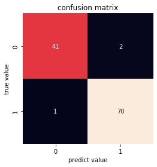

```python
sns.heatmap(matric,square=True,annot=True,cbar=False)
plt.xlabel("predict value")
plt.ylabel("true value")
plt.title("confusion matrix")
plt.show()
```

```python
print("report:\n",classification_report(y_test,predict,labels=[1,0],target_names=["良性","惡性"]))
```

```
report:
               precision    recall  f1-score   support

          良性       0.97      0.99      0.98        71
          惡性       0.98      0.95      0.96        43

    accuracy                           0.97       114
   macro avg       0.97      0.97      0.97       114
weighted avg       0.97      0.97      0.97       114
```

另外，對於這種分類模型，也可以使用 ROC curve 以及 AUC 來評估

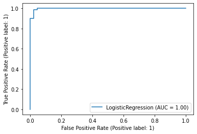

```python
from sklearn.metrics import roc_curve, auc, plot_roc_curve
plot_roc_curve(clf, x_test_std, y_test)
plt.show()
```

綜合不同模型的衡量指標來看，可以發現使用邏輯斯回歸的成效不錯，對於乳癌的預測具有良好的效果。

## 5. 參考資源

- RPubs Logistic Regression Ginger Zhan https://rpubs.com/ginger_zhan/logistic_regression
- sklearn logisticRegreesion https://scikit-learn.org/stable/modules/generated/sklearn.linear_model.LogisticRegression.html
- 機器學習-邏輯回歸(Logistic Regression) http://www.taroballz.com/2018/07/18/ML_LogisticRegression/